# Biostat 203B Homework 1

## Q4. Who’s popular in Pride and Prejudice

1. You and your friend just have finished reading *Pride and Prejudice* by Jane Austen. Among the four main characters in the book, Elizabeth, Jane, Lydia, and Darcy, your friend thinks that Darcy was the most mentioned. You, however, are certain it was Elizabeth. Obtain the full text of the novel from http://www.gutenberg.org/cache/epub/42671/pg42671.txt and save to your local folder.

```bash
wget -nc http://www.gutenberg.org/cache/epub/42671/pg42671.txt
```

Explain what `wget -nc` does. Do **not** put this text file `pg42671.txt` in Git. Complete the following loop to tabulate the number of times each of the four characters is mentioned using Linux commands.

- wget: is a command which allows for downloading files directly from the internet to your working directory & then saves it with the same name as teh specific online server
  - had to install Homebrew & then wget command

```bash
wget -nc http://www.gutenberg.org/cache/epub/42671/pg42671.txt
for char in Elizabeth Jane Lydia Darcy
do
  echo "$char:"
  grep -o -i "$char" pg42671.txt | wc -l  # some bash commands here
done
```

```
File ‘pg42671.txt’ already there; not retrieving.

Elizabeth:
     634
Jane:
     293
Lydia:
     171
Darcy:
     418
```

2. What’s the difference between the following two commands?
- The following command overwrites the previous file with new content as new file test1.txt with “hello, world”
- It will overwrite the file if one previously exists

```bash
echo 'hello, world' > test1.txt
```

and

- The following file appends/adds a new file test2.txt if it doesn’t exist
- If it already exists, it adds the line to the end without deleting the previous content

```bash
echo 'hello, world' >> test2.txt
```

3. Using your favorite text editor (e.g., `vi`), type the following and save the file as `middle.sh`:

```bash
#!/bin/sh
# Select lines from the middle of a file.
# Usage: bash middle.sh filename end_line num_lines
head -n "$2" "$1" | tail -n "$3"
```

Using `chmod` to make the file executable by the owner, and run

```bash
cd ~/Documents/biostat-20b-2026-winter/hw1
chmod u+x middle.sh
ls -l middle.sh
./middle.sh pg42671.txt 20 5
```

```
-rwxr--r--  1 charlottelee  staff  136 Jan 25 18:31 middle.sh

Release date: May 9, 2013 [eBook #42671]
                Most recently updated: January 25, 2026

Language: English
```

Explain the output. Explain the meaning of `"$1"`, `"$2"`, and `"$3"` in this shell script. Why do we need the first line of the shell script?

- The output represents lines 16-20 of the pg.42671.txt file. It selects the first 20 lines as a set and then clips the last 5 lines of that subset.
- The $1 represents the file name (pg.42671.txt). The $2 represents the value of the line number we want up to so that would be 20 in this case. Then the $3 represents the number of lines from the bottom of the subset we want to keep (5 lines).
- The first line #!/bin/sh represents the operating system that is needed to run the script. It uses the standard shell interpreter (sh) to make sure that it can execute ./middle.sh.

## Q5. More fun with Linux

Try following commands in Bash and interpret the results: `cal`, `cal 2026`, `cal 9 1752` (anything unusual?), `date`, `hostname`, `arch`, `uname -a`, `uptime`, `who am i`, `who`, `w`, `id`, `last | head`, `echo {con,pre}{sent,fer}{s,ed}`, `time sleep 5`, `history | tail`.

```bash
#This gives a month calender highlighting the specific day of the month
cal

#This gives a full year calender highlighting the specific day of the month & year
cal 2026

#This gives the month calender of September 1752.(It skips days 3-13.)
cal 9 1752

#Outputs my mac book name/model
hostname

#Outputs the code name
arch

#Outputs the model, year, more specifc details of my specific macbook version and usage history
uname -a

#Ouputs the currentime in 24-hr format, system run time, number of users, and load averages
uptime

#Outputs my name/username and the date/time of day
who am i

#Outputs my username, type of terminal, and login time
who

#My system overview: current time, system uptime, users, load averages, username, type of terminal,ip address, time of user login, how long user has been idle, the program in use
w

#Provides a detailed personal information of my ID's including username, userID, groupID, and roup memberships (if available)
id

#Shows login history of user on system as well as reboots/terminal activities & shows the first 10 lines of output from the last command used
last | head

#Generates strings that are possible from the combinarions of taking one choice from each set of brackets
echo {con,pre}{sent,fer}{s,ed}

#Measures how long it takes for sleep command to run (pausing execution for 5 seconds)
time sleep 5

#Displays the last 10 commands used from my shell command history
history | tail
```

```
    January 2026
Su Mo Tu We Th Fr Sa
             1  2  3
 4  5  6  7  8  9 10
11 12 13 14 15 16 17
18 19 20 21 22 23 24
25 26 27 28 29 30 31

                            2026
      January               February               March
Su Mo Tu We Th Fr Sa  Su Mo Tu We Th Fr Sa  Su Mo Tu We Th Fr Sa
             1  2  3   1  2  3  4  5  6  7   1  2  3  4  5  6  7
 4  5  6  7  8  9 10   8  9 10 11 12 13 14   8  9 10 11 12 13 14
11 12 13 14 15 16 17  15 16 17 18 19 20 21  15 16 17 18 19 20 21
18 19 20 21 22 23 24  22 23 24 25 26 27 28  22 23 24 25 26 27 28
25 26 27 28 29 30 31                        29 30 31


       April                  May                   June
Su Mo Tu We Th Fr Sa  Su Mo Tu We Th Fr Sa  Su Mo Tu We Th Fr Sa
          1  2  3  4                  1  2      1  2  3  4  5  6
 5  6  7  8  9 10 11   3  4  5  6  7  8  9   7  8  9 10 11 12 13
12 13 14 15 16 17 18  10 11 12 13 14 15 16  14 15 16 17 18 19 20
19 20 21 22 23 24 25  17 18 19 20 21 22 23  21 22 23 24 25 26 27
26 27 28 29 30        24 25 26 27 28 29 30  28 29 30
                      31

        July                 August              September
Su Mo Tu We Th Fr Sa  Su Mo Tu We Th Fr Sa  Su Mo Tu We Th Fr Sa
          1  2  3  4                     1         1  2  3  4  5
 5  6  7  8  9 10 11   2  3  4  5  6  7  8   6  7  8  9 10 11 12
12 13 14 15 16 17 18   9 10 11 12 13 14 15  13 14 15 16 17 18 19
19 20 21 22 23 24 25  16 17 18 19 20 21 22  20 21 22 23 24 25 26
26 27 28 29 30 31     23 24 25 26 27 28 29  27 28 29 30
                      30 31

      October               November              December
Su Mo Tu We Th Fr Sa  Su Mo Tu We Th Fr Sa  Su Mo Tu We Th Fr Sa
             1  2  3   1  2  3  4  5  6  7         1  2  3  4  5
 4  5  6  7  8  9 10   8  9 10 11 12 13 14   6  7  8  9 10 11 12
```

[output cut: 21 more lines]

```
charlottelee ttys001                         Sat Jan 24 23:08 - 23:08  (00:00)
charlottelee ttys001                         Thu Jan 15 21:03 - 21:03  (00:00)
charlottelee ttys000                         Tue Oct 28 22:15 - 22:15  (00:00)
charlottelee console                         Sat Oct 18 16:23   still logged in
reboot time                                Sat Oct 18 16:23
charlottelee ttys000                         Sat Oct  4 16:48 - 16:48  (00:00)
charlottelee ttys000                         Sun Sep 28 14:54 - 14:54  (00:00)
charlottelee ttys000                         Mon Sep 22 08:45 - 08:45  (00:00)
charlottelee ttys000                         Wed Sep 17 08:43 - 08:43  (00:00)
charlottelee console                         Mon Sep  1 16:41 - crash (46+23:41)
consents consented confers confered presents presented prefers prefered

real    0m5.004s
user    0m0.001s
sys 0m0.001s
```

## Q6. Book

1. Git clone the repository https://github.com/christophergandrud/Rep-Res-Book for the book *Reproducible Research with R and RStudio* to your local machine. Do **not** put this repository within your homework repository `biostat-203b-2026-winter`.

```bash
cd ~/Downloads/winter2026_data
git clone https://github.com/christophergandrud/Rep-Res-Book.git
ls ~/Downloads/winter2026_data/Rep-Res-Book
```

2. Open the project by clicking `rep-res-3rd-edition.Rproj` and compile the book by clicking `Build Book` in the `Build` panel of RStudio. (Hint: I was able to build `git_book` and `epub_book` directly. For `pdf_book`, I needed to add a line `\usepackage{hyperref}` to the file `Rep-Res-Book/rep-res-3rd-edition/latex/preabmle.tex`.)

The point of this exercise is (1) to obtain the book for free and (2) to see an example how a complicated project such as a book can be organized in a reproducible way. Use `sudo apt install PKGNAME` to install required Ubuntu packages and `tlmgr install PKGNAME` to install missing TexLive packages.

For grading purpose, include a screenshot of Section 4.1.5 of the book here.

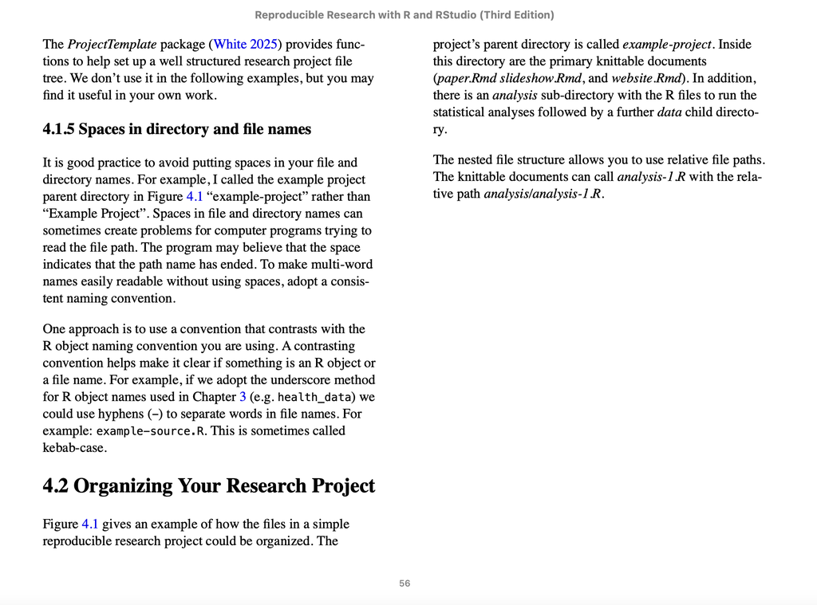

## Q7. AI assistant

Which AI assistants (e.g., GitHub Copilot) do you use when working on this assignment? Which AI model (e.g., GPT-5 mini, GPT-5, Claude Sonnet 4.5) does the AI assistant use? How do you use them? Do you think they help improve your productivity?

Give 5 instances where AI model gave incorrect or misleading answers. You can use screenshots or copy-paste the Q&A.

- I used GitHub Copilot and GPT-5. I treied to use Claude Sonnet but it was quite slow for me so I switched back to GPT.
- I used them when I had errors in my bash command code lines like when I got a warning or a red message specifically in question 3 where I had the most trouble:
- For screenshot 1 the zcat command would not work for me but it kept on suggesting it and the path assumed it was just mimic
- For the second screenshot 2, the find function wasn’t allowed for this folder and said that the permission was not allowed but GPT kept telling me to use the find command
- For screenshot 3 (and 2) it assumed that mimic was in the Documents folder even though it was in my downloads folder

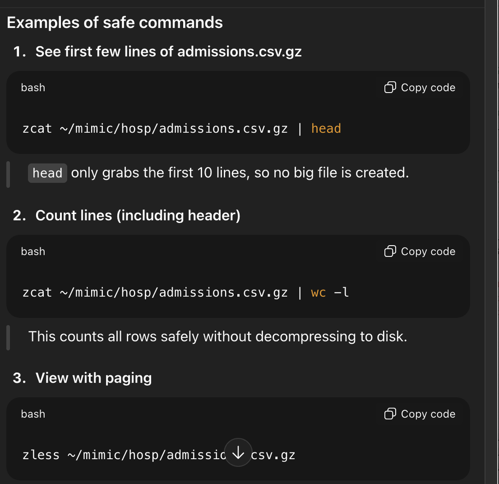

[figure not shown]

[figure not shown]